# Intro to RefSeeker - Obtain stability ranking from raw expression data

The RefSeeker package provides a convenient way of analyzing target stabilities from raw Cp/Ct/Cq values expression data of set of samples. It uses the RefFinder[1] method which includes stability values calculated by four different algorithms: Normfinder[2], geNorm[3], BestKeeper[4] and the comparative delta-Ct method[5]. The target stabilities are then ranked and a geometric mean of the ranking from each algorithm is then calculated as the comprehensive ranking.

The package include functions for easy import of raw data, extraction of stability values for each algorithm and an easy way of exporting these data either for further use. Either in the form of excel files or as csv files.

After installation the library is loaded as all other packages.

```r
library(RefSeeker)
```

The function contained in the RefSeeker package has all been given the prefix “rs”. Function that are meant to be used by user has the prefix “rs_”. The “rs” without the underscore are mostly helpers for the other functions.

## Data input requirements

Input data can be prepared in a number of ways. The data do not need to be imported if the preparation is handled in R. In this case data should be prepared in the form of matrices, data frames or a tibbles.

Input data can also be provided in the form of the following supported file types; xlsx, xls, ods, csv, tsc, txt.

More than one file can be selected for comparison or as individual parallel analyses.

No matter the input source, the following requirements are the same:

- Each column must be representing a gene/target and each row representing an individual sample.
- Each column must be named.
- Row names must be excluded
- No missing data is allowed

### Load data from file

Data can be loaded using the rs_loaddata function, a file selection dialog will appear if a file path is not provided, please see the “Loading data sources” vignette for further information.

## Analysing a single expreiment

A randomly generated example can be seen below:

```r
set.seed(100)
ct_vals <- matrix(rnorm(5*20, mean = 25), ncol = 5, nrow = 20)
dimnames(ct_vals)[[2]] <-  c("gene1", "gene2", "gene3", "gene4", "gene5")
ct_vals
```

```
#>          gene1    gene2    gene3    gene4    gene5
#>  [1,] 24.49781 24.56191 24.89837 24.73800 25.89682
#>  [2,] 25.13153 25.76406 26.40320 24.93116 24.95000
#>  [3,] 24.92108 25.26196 23.22322 24.62112 23.65465
#>  [4,] 25.88678 25.77340 25.62287 27.58196 23.06879
#>  [5,] 25.11697 24.18562 24.47772 25.12983 25.70958
#>  [6,] 25.31863 24.56155 26.32223 24.28698 24.84209
#>  [7,] 24.41821 24.27978 24.63656 25.63799 25.21637
#>  [8,] 25.71453 25.23094 26.31907 25.20169 25.81736
#>  [9,] 24.17474 23.84227 25.04378 24.93008 26.72718
#> [10,] 24.64014 25.24708 23.12134 24.90751 24.89623
#> [11,] 25.08989 24.90889 24.55294 25.44890 24.44288
#> [12,] 25.09627 26.75738 23.26140 23.93564 26.42830
#> [13,] 24.79837 24.86207 25.17886 23.83758 24.10704
#> [14,] 25.73984 24.88881 26.89747 26.64852 23.84243
#> [15,] 25.12338 24.30999 22.72807 22.93790 24.46970
#> [16,] 24.97068 24.77821 25.98046 25.01275 27.44568
#> [17,] 24.61115 25.18291 23.60117 23.91247 24.16750
#> [18,] 25.51086 25.41732 26.82487 25.27054 25.41352
#> [19,] 24.08619 26.06540 26.38130 26.00845 23.82132
#> [20,] 27.31030 25.97020 24.16115 22.92560 23.82597
```

To obtain the RefSeeker results run:

```r
rs_results <- rs_reffinder(ct_vals)
```

```
#> Please note that the target names has been factorized based on the appearance in the input dataset
```

```r
rs_results
```

```
#> $stabilityTable
#>   Target delta-Ct BestKeeper Normfinder geNorm Comprehensive Rank
#> 1  gene2    1.292      0.575      0.787  0.826              1.189
#> 2  gene1    1.295      0.488      0.791  0.826              1.414
#> 3  gene4    1.402      0.797      0.981  1.180              3.000
#> 4  gene3    1.453      1.116      1.073  1.276              4.229
#> 5  gene5    1.614      0.917      1.332  1.411              4.729
#>
#> $rankTable
#>   Target delta-Ct BestKeeper Normfinder geNorm Comprehensive Rank
#> 1  gene2        1          2          1      1                  1
#> 2  gene1        2          1          2      1                  2
#> 3  gene4        3          3          3      3                  3
#> 4  gene3        4          5          4      4                  4
#> 5  gene5        5          4          5      5                  5
```

This produces a list of two tables. A table containing target stability values for each algorithm and a ranking table that ranks the most stable from 1 to N number of targets.

## Table export

To export the table the function rs_exporttable() is available.

Main arguments are the rs_reffinder results and a table type which can be any of:

“xlsx”, “ods, csv”, “tsv”, “txt”, “docx-stability”, “docx-rank” or “docx-combi”.

Depending on the selected table type one or files per data set is created. Please see the “Export stability results” vignettes for further information.  
Two examples of the rs_exporttable() can be seen below.  
To create an excel file containing the tables:

```r
rs_exporttable(rs_results, "./output/folder/sample_excel_tables", tabletype = "xlsx")
```

The two tables will appear in the excel file as separate sheets with filter options.

To create a formatted table in a docx file:

```r
rs_exporttable(rs_results, "./output/folder/sample_docx-combi_table", tabletype = "docx-combi")
```

A docx document with the formatted table has now been created given path.

## Creating a graph

For a graphical representation rs_graph() can be used. This has several available tweaks to control output including file types, orientation of bars and the option for adding specific colors to specific targets. Please see the “Export stability graphs” vignette for further information. For a nice visualization of the stabilities, use:

[output not shown]

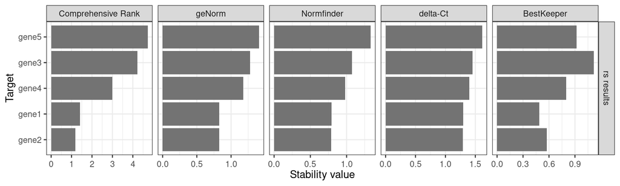

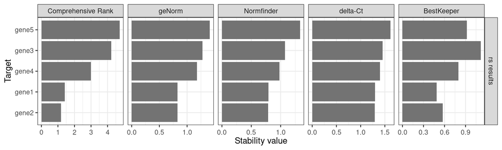

```r
rs_graph(rs_results)
```

To print the graph as a Png file, just add a file name and select a file type.

File types can be any of: “png”, “tiff”, “jpeg” or “svg”.

```r
rs_graph(rs_results, "./output/folder/Sample stability", filetype = "png")
```

Et voilà! Now you can select the targets with the lowest stability value as reference genes for your expression studies

## The Wizard

To perform a quick and guided analysis, there is one function to rule them all: the rs_wizard()

By running this, a dialog will appear (note: It has been observed that on windows machines, the dialog window are not always sent to the foreground and may hide underneath other open windows).

The rs_wizard dialog will provide a simple an easy interface for selecting input files, output directory, file name prefix, graph type, ordering of the targets on the target axis, orientation of the bars, graph output format and table output format.

Note that some functionalities are limited. It is so far only possible to import from data files and options like color and parameters like dimension of the graph can not be adjusted yet.

```r
rs_wizard()
```

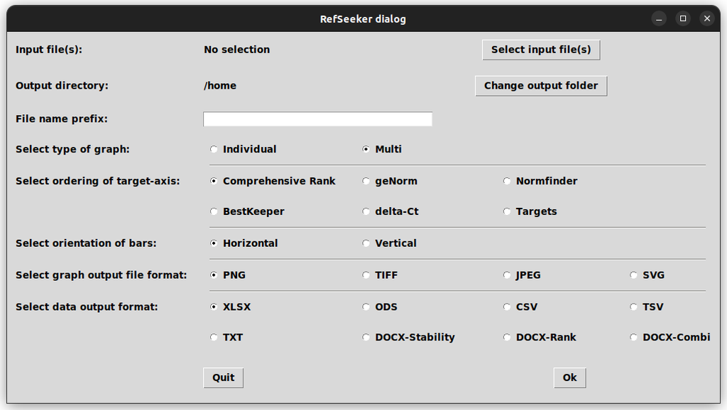

[1]

[F. Xie, P. Xiao, D. Chen, L. Xu, B. Zhang, Plant Molecular Biology 80 (2012) 75–84](https://doi.org/10.1007/s11103-012-9885-2).

[2]

[C.L. Andersen, J.L. Jensen, T.F. Ørntoft, Cancer Research 64 (2004) 5245–5250](https://doi.org/10.1158/0008-5472.CAN-04-0496).

[3]

[J. Vandesompele, K. De Preter, F. Pattyn, B. Poppe, N. Van Roy, A. De Paepe, F. Speleman, Genome Biology 3 (2002)](https://doi.org/10.1186/gb-2002-3-7-research0034).

[4]

[M.W. Pfaffl, A. Tichopad, C. Prgomet, T.P. Neuvians, Biotechnology Letters 26 (2004) 509–515](https://doi.org/10.1023/B:BILE.0000019559.84305.47).

[5]

[N. Silver, S. Best, J. Jiang, S.L. Thein, BMC Molecular Biology 7 (2006) 1–9](https://doi.org/10.1186/1471-2199-7-33).